# Final Project Report

Manojkumar Mohankumar

## Instructions

This is the data analysis code book for the final project. The topic for the final project: **Gender Pay Gap Analysis Using Statistical and Predictive Modeling** The data for analysis: **https://www.kaggle.com/datasets/nilimajauhari/glassdoor-analyze-gender-pay-gap**

## Data Processing

```r
data <- read.csv("./glassdoor-gender-pay-gap.csv")
data$Gender <- factor(data$Gender)
data$Dept <- factor(data$Dept)
head(data)
```

```
##              JobTitle Gender Age PerfEval Education           Dept Seniority
## 1    Graphic Designer Female  18        5   College     Operations         2
## 2   Software Engineer   Male  21        5   College     Management         5
## 3 Warehouse Associate Female  19        4       PhD Administration         5
## 4   Software Engineer   Male  20        5   Masters          Sales         4
## 5    Graphic Designer   Male  26        5   Masters    Engineering         5
## 6                  IT Female  20        5       PhD     Operations         4
##   BasePay Bonus
## 1   42363  9938
## 2  108476 11128
## 3   90208  9268
## 4  108080 10154
## 5   99464  9319
## 6   70890 10126
```

### Data Cleaning

```r
# Create an column that is the sum of base pay + bonus = full salary
data$Salary <- data$BasePay +  data$Bonus


# Remove outliers
data <- data %>%
  filter(between(Salary,
                 quantile(Salary, 0.25) - 1.4 * IQR(Salary), # 1.4*IQR to be more conservative
                 quantile(Salary, 0.75) + 1.4 * IQR(Salary)))
```

### Descriptive Data

1. Distribution of Job titles

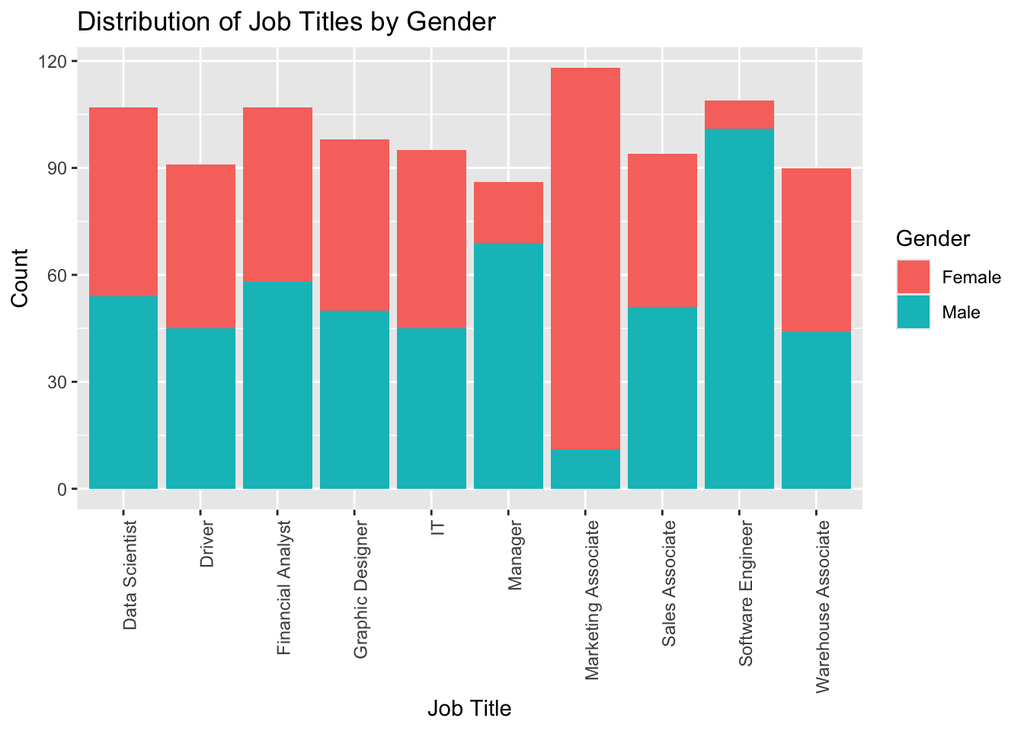

```r
ggplot(data, aes(x = JobTitle, fill = Gender)) +
  geom_bar() +
  theme(axis.text.x = element_text(angle = 90, hjust = 1)) +
  labs(
    title = "Distribution of Job Titles by Gender",
    x = "Job Title",
    y = "Count",
    fill = "Gender"
  )
```

2. Distribution of Salaries for male and female

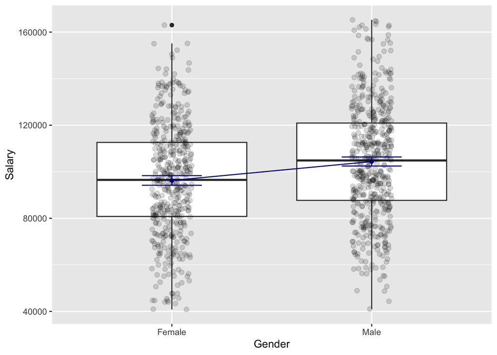

```r
ggplot(data, aes(x = Gender, y = Salary)) +
  geom_boxplot() +
  geom_point(position = position_jitter(width = .1), alpha = .15, size = 2) +
  stat_summary(fun = mean, geom = "point", color = "darkblue") + # add the mean as a point
  stat_summary(fun = mean, geom = "line", aes(group = "BeforeOrAfter"), color = "darkblue") + # add the line between groups
  stat_summary(fun.data = mean_cl_boot, geom = "errorbar", width = 0.3, color = "darkblue") +  # add error bars
  labs(x = "Gender",
       y = "Salary") # rename x- and y-axis
```

3. Colinearity Checking

```r
data
```

[output not shown]

[output cut: 1977 more lines]

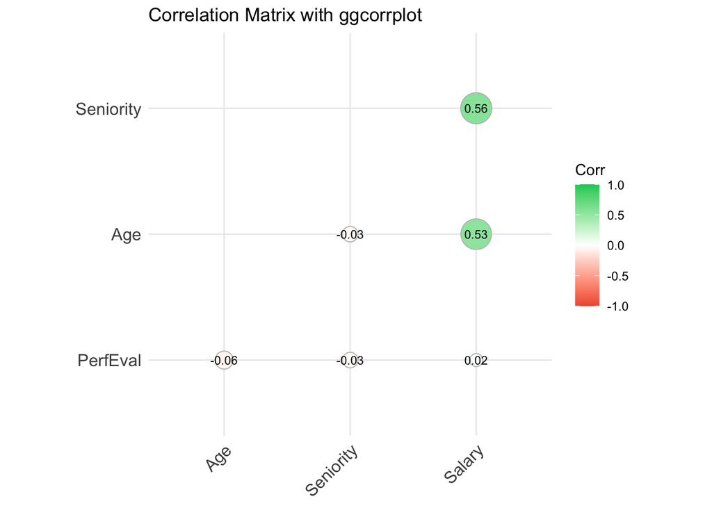

```r
data_cor <- data %>% select(Age, PerfEval, Seniority, Salary)


mixed_corr <- mixedCor(data_cor)$rho
# cor_matrix <- cor(data_cor,
                  #use = "pairwise.complete.obs")

ggcorrplot(mixed_corr, hc.order = TRUE, type = "lower",
           lab = TRUE, lab_size = 3, method="circle",
           colors = c("tomato2", "white", "springgreen3"),
           title="Correlation Matrix with ggcorrplot",
           ggtheme=ggplot2::theme_minimal())
```

## RQ1: Is there evidence of the gender pay gap across job titles, departments, and education levels?

```r
## Assumption checking for t-test
female <- data %>% filter(Gender=="Female")
male <- data %>% filter(Gender=="Male")

### Normality (shapiro-wilk test)
shapiro.test(female$Salary)
```

```
##
##  Shapiro-Wilk normality test
##
## data:  female$Salary
## W = 0.99528, p-value = 0.1678
```

```r
shapiro.test(male$Salary)
```

```
##
##  Shapiro-Wilk normality test
##
## data:  male$Salary
## W = 0.99459, p-value = 0.0592
```

```r
# -> the normality is met

### Homogeneity of Variance
leveneTest(Salary ~ Gender, data = data)
```

```
## Levene's Test for Homogeneity of Variance (center = median)
##        Df F value Pr(>F)
## group   1  0.3088 0.5785
##       993
```

```r
# -> the homogeneity of variance is met
```

```r
## t-test between male vs. female overall

female <- data %>% filter(Gender=="Female")
male <- data %>% filter(Gender=="Male")

## -> We can run Student's t-test
res <- t.test(male$Salary, female$Salary, var.equal = TRUE)
res
```

```
##
##  Two Sample t-test
##
## data:  male$Salary and female$Salary
## t = 5.249, df = 993, p-value = 1.87e-07
## alternative hypothesis: true difference in means is not equal to 0
## 95 percent confidence interval:
##   5080.382 11147.148
## sample estimates:
## mean of x mean of y
## 104375.24  96261.48
```

```r
effectsize(res)
```

```
## Cohen's d |       95% CI
## ------------------------
## 0.33      | [0.21, 0.46]
##
## - Estimated using pooled SD.
```

### ANOVA between male vs. female across different job titles

```r
## ANOVA between male vs. female across different job titles
model <- aov(Salary ~ Gender * JobTitle, data)


### Check the assumptions
### -> Normality of Residuals
res <- residuals(model)
shapiro.test(res)
```

```
##
##  Shapiro-Wilk normality test
##
## data:  res
## W = 0.99555, p-value = 0.005521
```

```r
### -> Check the homogeneity of variance
leveneTest(Salary ~ Gender * JobTitle, data)
```

```
## Levene's Test for Homogeneity of Variance (center = median)
##        Df F value Pr(>F)
## group  19   0.987 0.4738
##       975
```

```r
### -> homogeneity of variance is met
### -> Normality of residuals are not met
```

```r
## Because the assumption of normality of residual violated,
## We will use Scheirer–Ray–Hare Test (SRH Test) -> non-parametric substitute for a two-way ANOVA
scheirerRayHare(Salary ~ Gender * JobTitle, data=data)
```

```
##
## DV:  Salary
## Observations:  995
## D:  0.9999999
## MS total:  82585
```

```
##                  Df   Sum Sq       H p.value
## Gender            1    16765   0.203  0.6523
## JobTitle          9 13887336 168.158  0.0000
## Gender:JobTitle   9   734615   8.895  0.4470
## Residuals       975 65523243
```

```r
## Post-hoc test
res <- dunn_test(Salary ~ JobTitle, data=data)

dunn_results_clean <- res %>%
  dplyr::select(group1, group2, statistic, p.adj) %>%
  dplyr::rename(
    "Job Title 1" = group1,
    "Job Title 2" = group2,
    "Z statistic" = statistic,
    "Adjusted p-value" = p.adj
  )

write.csv(
  dunn_results_clean,
  "Dunn_Test_Results_Appendix.csv",
  row.names = FALSE
)
```

### ANOVA between male vs. female across different department

```r
## ANOVA between male vs. female across different Deptartment
model <- aov(Salary ~ Gender * Dept, data)

### Check the assumptions
### -> Normality of Residuals
res <- residuals(model)
shapiro.test(res)
```

```
##
##  Shapiro-Wilk normality test
##
## data:  res
## W = 0.99606, p-value = 0.01246
```

```r
### -> Check the homogeneity of variance
leveneTest(Salary ~ Gender * Dept, data)
```

```
## Levene's Test for Homogeneity of Variance (center = median)
##        Df F value Pr(>F)
## group   9  0.6711 0.7357
##       985
```

```r
## Because the assumption of normality of residual violated,
## We will use Scheirer–Ray–Hare Test (SRH Test) -> non-parametric substitute for a two-way ANOVA
scheirerRayHare(Salary ~ Gender * Dept, data=data)
```

```
##
## DV:  Salary
## Observations:  995
## D:  0.9999999
## MS total:  82585
```

```
##              Df   Sum Sq       H p.value
## Gender        1  1947685 23.5840 0.00000
## Dept          4   971410 11.7625 0.01921
## Gender:Dept   4    59449  0.7199 0.94886
## Residuals   985 79114336
```

```r
## Post-hoc test
res <- dunn_test(Salary ~ Dept, data=data)
dunn_results_clean <- res %>%
  dplyr::select(group1, group2, statistic, p.adj) %>%
  dplyr::rename(
    "Job Title 1" = group1,
    "Job Title 2" = group2,
    "Z statistic" = statistic,
    "Adjusted p-value" = p.adj
  )

write.csv(
  dunn_results_clean,
  "Dunn_Test_Results_Appendix.csv",
  row.names = FALSE
)
```

### ANOVA between male vs. female across different Education

```r
## ANOVA between male vs. female across different education levels
model <- aov(Salary ~ Gender * Education, data)

### Check the assumptions
### -> Normality of Residuals
res <- residuals(model)
shapiro.test(res)
```

```
##
##  Shapiro-Wilk normality test
##
## data:  res
## W = 0.99757, p-value = 0.1486
```

```r
### -> Check the homogeneity of variance
leveneTest(Salary ~ Gender * Education, data)
```

```
## Levene's Test for Homogeneity of Variance (center = median)
##        Df F value  Pr(>F)
## group   7   1.834 0.07746 .
##       987
## ---
## Signif. codes:  0 '***' 0.001 '**' 0.01 '*' 0.05 '.' 0.1 ' ' 1
```

```r
summary(model)
```

```
##                   Df    Sum Sq   Mean Sq F value   Pr(>F)
## Gender             1 1.631e+10 1.631e+10  28.293 1.29e-07 ***
## Education          3 1.712e+10 5.706e+09   9.896 1.97e-06 ***
## Gender:Education   3 1.746e+09 5.821e+08   1.009    0.388
## Residuals        987 5.691e+11 5.766e+08
## ---
## Signif. codes:  0 '***' 0.001 '**' 0.01 '*' 0.05 '.' 0.1 ' ' 1
```

```r
## Post-hoc test
TukeyHSD(model, "Education")
```

```
##   Tukey multiple comparisons of means
##     95% family-wise confidence level
##
## Fit: aov(formula = Salary ~ Gender * Education, data = data)
##
## $Education
##                          diff        lwr       upr     p adj
## High School-College -4159.888 -9665.3433  1345.568 0.2102193
## Masters-College      4383.608 -1168.0191  9935.235 0.1769245
## PhD-College          6527.614   862.3636 12192.864 0.0163450
## Masters-High School  8543.496  3117.6218 13969.370 0.0003189
## PhD-High School     10687.501  5145.4256 16229.577 0.0000049
## PhD-Masters          2144.006 -3443.9390  7731.950 0.7566900
```

## RQ2: Which organizational and employee factors best explain variations in the gender pay gap?

- We are going to use regression to tell

```r
## Using multiple regression to explain the variation in the gender pay gap
## Base model
model_base <- lm(Salary ~ Gender, data = data)
summary(model_base)
```

```
##
## Call:
## lm(formula = Salary ~ Gender, data = data)
##
## Residuals:
##    Min     1Q Median     3Q    Max
## -63345 -16194    375  16402  66750
##
## Coefficients:
##             Estimate Std. Error t value Pr(>|t|)
## (Intercept)    96262       1126  85.487  < 2e-16 ***
## GenderMale      8114       1546   5.249 1.87e-07 ***
## ---
## Signif. codes:  0 '***' 0.001 '**' 0.01 '*' 0.05 '.' 0.1 ' ' 1
##
## Residual standard error: 24330 on 993 degrees of freedom
## Multiple R-squared:  0.027,  Adjusted R-squared:  0.02602
## F-statistic: 27.55 on 1 and 993 DF,  p-value: 1.87e-07
```

```r
## Model with organizational factors
model_org <- lm(Salary ~ Gender + Dept + JobTitle, data = data)
summary(model_org)
```

```
##
## Call:
## lm(formula = Salary ~ Gender + Dept + JobTitle, data = data)
##
## Residuals:
##    Min     1Q Median     3Q    Max
## -55615 -15448   -221  14682  52817
##
## Coefficients:
##                             Estimate Std. Error t value Pr(>|t|)
## (Intercept)                  98002.1     2618.1  37.432  < 2e-16 ***
## GenderMale                    -655.9     1539.0  -0.426   0.6701
## DeptEngineering               3782.1     2230.4   1.696   0.0903 .
## DeptManagement                1274.5     2231.5   0.571   0.5680
## DeptOperations               -2934.2     2179.9  -1.346   0.1786
## DeptSales                     5130.2     2198.9   2.333   0.0198 *
## JobTitleDriver               -3492.5     3114.2  -1.121   0.2624
## JobTitleFinancial Analyst     2978.9     2988.2   0.997   0.3191
## JobTitleGraphic Designer     -1395.1     3055.4  -0.457   0.6481
## JobTitleIT                   -2981.5     3079.6  -0.968   0.3332
## JobTitleManager              30383.2     3200.6   9.493  < 2e-16 ***
## JobTitleMarketing Associate -16974.4     2986.2  -5.684 1.73e-08 ***
## JobTitleSales Associate        780.6     3090.6   0.253   0.8007
## JobTitleSoftware Engineer    13083.3     3046.0   4.295 1.92e-05 ***
## JobTitleWarehouse Associate  -2246.1     3123.6  -0.719   0.4723
## ---
## Signif. codes:  0 '***' 0.001 '**' 0.01 '*' 0.05 '.' 0.1 ' ' 1
##
## Residual standard error: 21820 on 980 degrees of freedom
## Multiple R-squared:  0.2278, Adjusted R-squared:  0.2168
## F-statistic: 20.65 on 14 and 980 DF,  p-value: < 2.2e-16
```

```r
## Relative importance analysis
# calc.relimp(model_full, type = "lmg")
rsq.partial(model_org)
```

```
## $adjustment
## [1] FALSE
##
## $variable
## [1] "Gender"   "Dept"     "JobTitle"
##
## $partial.rsq
## [1] 0.0001853067 0.0172375504 0.1953888104
```

```r
## Model with employee factors
model_emp <- lm(Salary ~ Gender + Seniority + PerfEval + Age, data = data)
summary(model_emp)
```

```
##
## Call:
## lm(formula = Salary ~ Gender + Seniority + PerfEval + Age, data = data)
##
## Residuals:
##    Min     1Q Median     3Q    Max
## -42262 -10438  -1157   9408  45259
##
## Coefficients:
##             Estimate Std. Error t value Pr(>|t|)
## (Intercept) 24550.11    2217.90  11.069   <2e-16 ***
## GenderMale   9736.56     973.81   9.998   <2e-16 ***
## Seniority    9759.39     348.13  28.034   <2e-16 ***
## PerfEval      799.89     341.81   2.340   0.0195 *
## Age           956.24      34.04  28.090   <2e-16 ***
## ---
## Signif. codes:  0 '***' 0.001 '**' 0.01 '*' 0.05 '.' 0.1 ' ' 1
##
## Residual standard error: 15280 on 990 degrees of freedom
## Multiple R-squared:  0.6176, Adjusted R-squared:  0.616
## F-statistic: 399.7 on 4 and 990 DF,  p-value: < 2.2e-16
```

```r
## Relative importance analysis
# calc.relimp(model_full, type = "lmg")
rsq.partial(model_emp)
```

```
## $adjustment
## [1] FALSE
##
## $variable
## [1] "Gender"    "Seniority" "PerfEval"  "Age"
##
## $partial.rsq
## [1] 0.091717302 0.442534733 0.005501282 0.443529676
```

## RQ3: Does higher education or performance evaluation mitigate the gender pay gap?

```r
model_rq3 <- lm(Salary ~ Gender * Education +
                  Gender * PerfEval +
                  Seniority + Age + JobTitle + Dept, data = data)
summary(model_rq3)
```

```
##
## Call:
## lm(formula = Salary ~ Gender * Education + Gender * PerfEval +
##     Seniority + Age + JobTitle + Dept, data = data)
##
## Residuals:
##    Min     1Q Median     3Q    Max
## -33719  -6961    409   7078  28078
##
## Coefficients:
##                                 Estimate Std. Error t value Pr(>|t|)
## (Intercept)                      21441.1     2178.5   9.842  < 2e-16 ***
## GenderMale                        2712.8     1949.2   1.392  0.16433
## EducationHigh School              -506.0     1272.3  -0.398  0.69094
## EducationMasters                  4231.7     1334.5   3.171  0.00157 **
## EducationPhD                      7549.1     1344.0   5.617 2.54e-08 ***
## PerfEval                          1385.0      329.0   4.210 2.79e-05 ***
## Seniority                         9843.9      231.4  42.536  < 2e-16 ***
## Age                                942.1       22.5  41.862  < 2e-16 ***
## JobTitleDriver                   -3853.7     1439.3  -2.677  0.00754 **
## JobTitleFinancial Analyst         3544.9     1383.6   2.562  0.01055 *
## JobTitleGraphic Designer         -2380.8     1417.5  -1.680  0.09335 .
## JobTitleIT                       -2429.6     1423.1  -1.707  0.08809 .
## JobTitleManager                  30948.4     1485.0  20.841  < 2e-16 ***
## JobTitleMarketing Associate     -16982.1     1379.6 -12.309  < 2e-16 ***
## JobTitleSales Associate            401.3     1427.0   0.281  0.77862
## JobTitleSoftware Engineer        13468.6     1404.8   9.587  < 2e-16 ***
## JobTitleWarehouse Associate       -509.8     1443.8  -0.353  0.72412
## DeptEngineering                   3201.6     1031.8   3.103  0.00197 **
## DeptManagement                    2711.0     1030.3   2.631  0.00864 **
## DeptOperations                    -639.7     1010.5  -0.633  0.52689
## DeptSales                         5947.1     1017.5   5.845 6.93e-09 ***
## GenderMale:EducationHigh School  -1952.3     1822.0  -1.072  0.28418
## GenderMale:EducationMasters        490.8     1845.4   0.266  0.79032
## GenderMale:EducationPhD          -3184.5     1862.1  -1.710  0.08755 .
## GenderMale:PerfEval               -402.8      454.9  -0.885  0.37615
## ---
## Signif. codes:  0 '***' 0.001 '**' 0.01 '*' 0.05 '.' 0.1 ' ' 1
##
## Residual standard error: 10050 on 970 degrees of freedom
## Multiple R-squared:  0.8378, Adjusted R-squared:  0.8338
## F-statistic: 208.8 on 24 and 970 DF,  p-value: < 2.2e-16
```

**The effect of education on salary does NOT differ between men and women.** **The effect of performance evaluation on salary does NOT differ between men and women.** **The interaction between gender and PhD was marginally significant (p = 0.087, still bigger than 0.05), suggesting a *possible trend* where the highest education level might slightly reduce the gender gap.**

## RQ4: Are women less likely to be among the top earners?

```r
## Define top 10% as the top earner
data <- data %>%
  mutate(
    TopEarner = Salary >= quantile(Salary, 0.90, na.rm = TRUE),
    TopEarner = factor(TopEarner,
                        levels = c(FALSE, TRUE),
                        labels = c("No", "Yes"))
  )

## Run the logistic regression
model_rq4 <- glm(TopEarner ~ Gender + Seniority + Age + JobTitle + Dept + Education + PerfEval,
                 data = data, family = "binomial")

summary(model_rq4)
```

```
##
## Call:
## glm(formula = TopEarner ~ Gender + Seniority + Age + JobTitle +
##     Dept + Education + PerfEval, family = "binomial", data = data)
##
## Coefficients:
##                              Estimate Std. Error z value Pr(>|z|)
## (Intercept)                 -23.61733    2.49015  -9.484  < 2e-16 ***
## GenderMale                   -1.05857    0.40827  -2.593 0.009520 **
## Seniority                     1.84565    0.21204   8.704  < 2e-16 ***
## Age                           0.20982    0.02427   8.645  < 2e-16 ***
## JobTitleDriver               -0.51464    0.85145  -0.604 0.545559
## JobTitleFinancial Analyst     0.58785    0.80553   0.730 0.465533
## JobTitleGraphic Designer     -0.26881    0.83951  -0.320 0.748817
## JobTitleIT                    0.45766    0.79182   0.578 0.563274
## JobTitleManager               6.15045    0.89877   6.843 7.74e-12 ***
## JobTitleMarketing Associate  -4.69026    1.47599  -3.178 0.001484 **
## JobTitleSales Associate       1.04576    0.78413   1.334 0.182315
## JobTitleSoftware Engineer     2.95718    0.79740   3.709 0.000208 ***
## JobTitleWarehouse Associate  -0.16067    0.88703  -0.181 0.856263
## DeptEngineering               1.98807    0.65513   3.035 0.002408 **
## DeptManagement                1.28916    0.66414   1.941 0.052244 .
## DeptOperations                0.46617    0.75201   0.620 0.535330
## DeptSales                     2.58741    0.67777   3.818 0.000135 ***
## EducationHigh School         -0.50607    0.54728  -0.925 0.355120
## EducationMasters              1.27290    0.51223   2.485 0.012955 *
## EducationPhD                  1.52265    0.50842   2.995 0.002746 **
## PerfEval                      0.38201    0.12250   3.119 0.001817 **
## ---
## Signif. codes:  0 '***' 0.001 '**' 0.01 '*' 0.05 '.' 0.1 ' ' 1
##
## (Dispersion parameter for binomial family taken to be 1)
##
##     Null deviance: 649.11  on 994  degrees of freedom
## Residual deviance: 234.08  on 974  degrees of freedom
## AIC: 276.08
##
## Number of Fisher Scoring iterations: 8
```

```r
exp(coef(model_rq4))
```

```
##                 (Intercept)                  GenderMale
##                5.535098e-11                3.469516e-01
##                   Seniority                         Age
##                6.332242e+00                1.233457e+00
##              JobTitleDriver   JobTitleFinancial Analyst
##                5.977152e-01                1.800105e+00
##    JobTitleGraphic Designer                  JobTitleIT
##                7.642889e-01                1.580369e+00
##             JobTitleManager JobTitleMarketing Associate
##                4.689262e+02                9.184294e-03
##     JobTitleSales Associate   JobTitleSoftware Engineer
##                2.845557e+00                1.924367e+01
## JobTitleWarehouse Associate             DeptEngineering
##                8.515716e-01                7.301464e+00
##              DeptManagement              DeptOperations
##                3.629753e+00                1.593871e+00
##                   DeptSales        EducationHigh School
##                1.329525e+01                6.028588e-01
##            EducationMasters                EducationPhD
##                3.571184e+00                4.584378e+00
##                    PerfEval
##                1.465226e+00
```

```r
data
```

[output not shown]

[output cut: 1977 more lines]

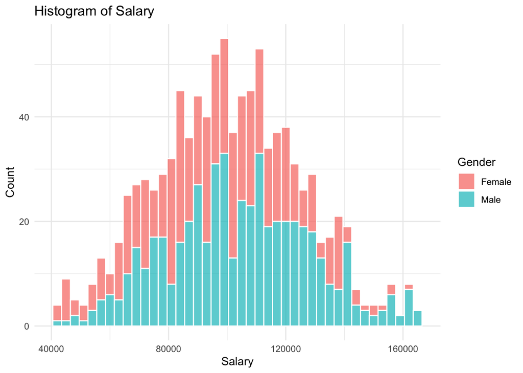

```r
ggplot(data, aes(x = Salary, fill = Gender)) +
  geom_histogram(binwidth = 3000, , color = "white", alpha = 0.7) +
  labs(title = "Histogram of Salary",
       x = "Salary",
       y = "Count") +
  theme_minimal()
```

## RQ5 - additional-> gender predict job titles

```r
data$Gender   <- factor(data$Gender)
data$JobTitle <- factor(data$JobTitle)

model <- multinom(JobTitle ~ Gender + Seniority + Age, data = data)
summary(model)
```

```
## Call:
## multinom(formula = JobTitle ~ Gender + Seniority + Age, data = data)
##
## Coefficients:
##                      (Intercept)  GenderMale    Seniority           Age
## Driver              -0.294643787 -0.03711696 -0.003492877  0.0038656186
## Financial Analyst    0.047156689  0.14682075 -0.004168948 -0.0027185714
## Graphic Designer    -0.213146735  0.02465605  0.081268916 -0.0032579137
## IT                  -0.008780129 -0.12539513 -0.052663778  0.0024966769
## Manager             -1.157446661  1.38258482 -0.041976102  0.0034115107
## Marketing Associate  0.638828048 -2.29183323  0.030321455 -0.0006668065
## Sales Associate     -0.463295095  0.15768136  0.010591199  0.0052459885
## Software Engineer   -1.881779407  2.51721105  0.002076780 -0.0003748319
## Warehouse Associate  0.173233095 -0.07206054  0.032169693 -0.0100732684
##
## Std. Errors:
##                     (Intercept) GenderMale  Seniority         Age
## Driver                0.5675383  0.2855099 0.10259903 0.010037641
## Financial Analyst     0.5404311  0.2742273 0.09832673 0.009608132
## Graphic Designer      0.5565394  0.2801042 0.10058484 0.009843961
## IT                    0.5569115  0.2824885 0.10164704 0.009926496
## Manager               0.6047010  0.3330078 0.10536419 0.010182025
## Marketing Associate   0.5391696  0.3711886 0.09831093 0.009751918
## Sales Associate       0.5660334  0.2835995 0.10170043 0.009941041
## Software Engineer     0.6345149  0.4153149 0.10007366 0.009657463
## Warehouse Associate   0.5613016  0.2866503 0.10282214 0.010106759
##
## Residual Deviance: 4350.894
## AIC: 4422.894
```

```r
Anova(model)
```

```
## Analysis of Deviance Table (Type II tests)
##
## Response: JobTitle
##           LR Chisq Df Pr(>Chisq)
## Gender     215.593  9     <2e-16 ***
## Seniority    2.343  9     0.9848
## Age          3.315  9     0.9505
## ---
## Signif. codes:  0 '***' 0.001 '**' 0.01 '*' 0.05 '.' 0.1 ' ' 1
```

```r
table(data$Gender, data$JobTitle)
```

```
##
##          Data Scientist Driver Financial Analyst Graphic Designer  IT Manager
##   Female             53     46                49               48  50      17
##   Male               54     45                58               50  45      69
##
##          Marketing Associate Sales Associate Software Engineer
##   Female                 107              43                 8
##   Male                    11              51               101
##
##          Warehouse Associate
##   Female                  46
##   Male                    44
```

```r
prop.table(table(data$Gender, data$JobTitle), margin = 1)
```

```
##
##          Data Scientist     Driver Financial Analyst Graphic Designer
##   Female     0.11349036 0.09850107        0.10492505       0.10278373
##   Male       0.10227273 0.08522727        0.10984848       0.09469697
##
##                  IT    Manager Marketing Associate Sales Associate
##   Female 0.10706638 0.03640257          0.22912206      0.09207709
##   Male   0.08522727 0.13068182          0.02083333      0.09659091
##
##          Software Engineer Warehouse Associate
##   Female        0.01713062          0.09850107
##   Male          0.19128788          0.08333333
```

## Additional Plots

```
## `height` was translated to `width`.
```

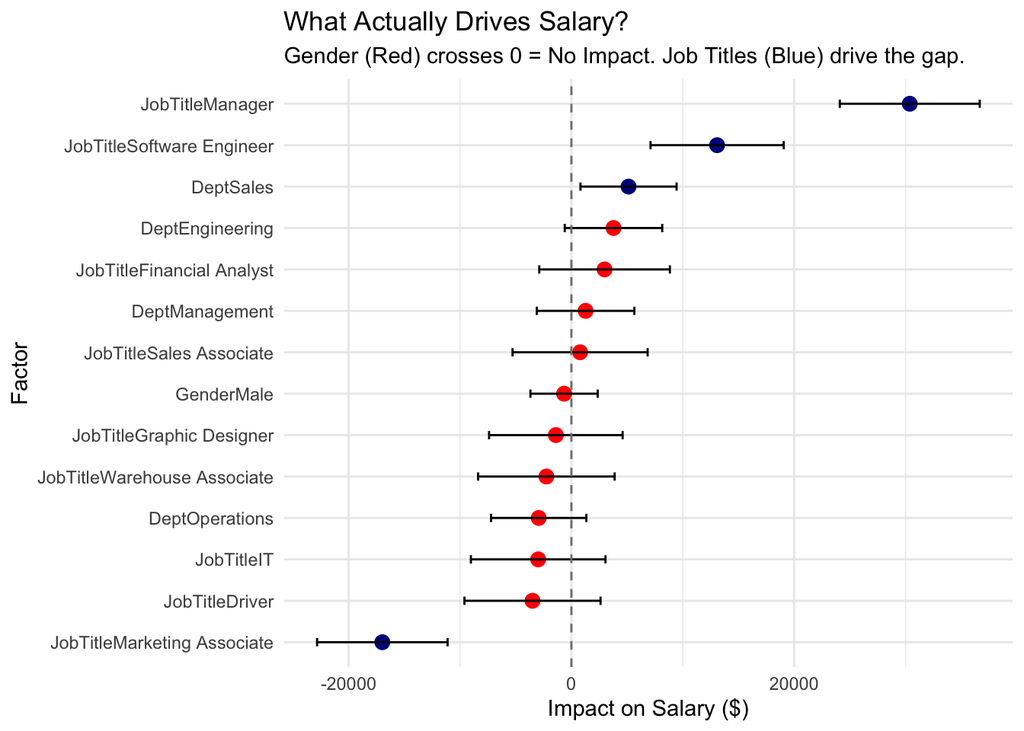

```r
# Code for RQ 2
library(ggplot2)
library(broom)

# Extract results from your Organizational Model
tidy_org <- tidy(model_org, conf.int = TRUE) %>%
  filter(term != "(Intercept)")

# Plot
ggplot(tidy_org, aes(x =estimate, y = reorder(term, estimate))) +
  geom_point(size = 3, color = ifelse(tidy_org$p.value < 0.05, "darkblue","red")) + # Blue if significant, Red if not
  geom_errorbarh(aes(xmin = conf.low, xmax = conf.high), height = 0.2) +
  geom_vline(xintercept = 0,linetype ="dashed", color = "gray50") +
  labs(title = "What Actually Drives Salary?",
       subtitle = "Gender (Red) crosses 0 = No Impact. Job Titles (Blue) drive the gap.",
       x = "Impact on Salary ($)",
       y = "Factor")+
  theme_minimal()
```

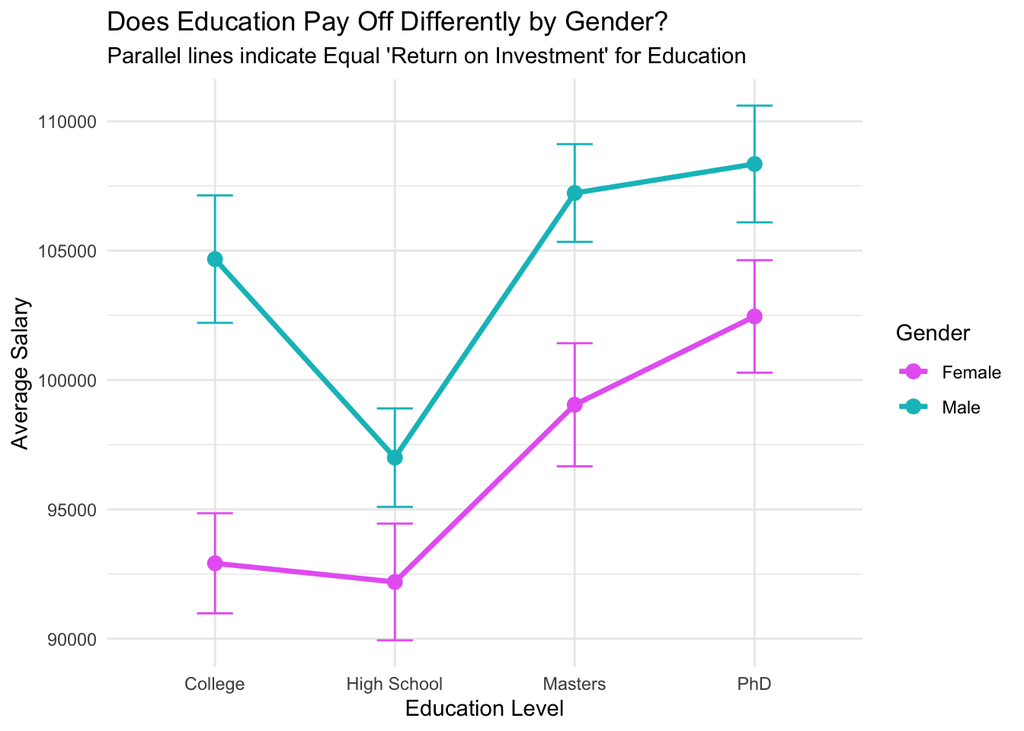

```r
# Code for RQ 3
# Plotting the Interaction between Gender and Education
ggplot(data, aes(x = Education, y = Salary, color = Gender, group = Gender)) +
  stat_summary(fun =mean, geom = "point", size = 3) +
  stat_summary(fun = mean, geom = "line",size = 1.2) +
  stat_summary(fun.data= mean_se, geom = "errorbar",width = 0.2) +
  labs(title = "Does Education Pay Off Differently by Gender?",
       subtitle = "Parallel lines indicate Equal 'Return on Investment' for Education",
       x = "Education Level",
       y = "Average Salary") +
  scale_color_manual(values = c("Female" = "#E76BF3","Male" = "#00BFC4")) +
  theme_minimal()
```

```
## `height` was translated to `width`.
```

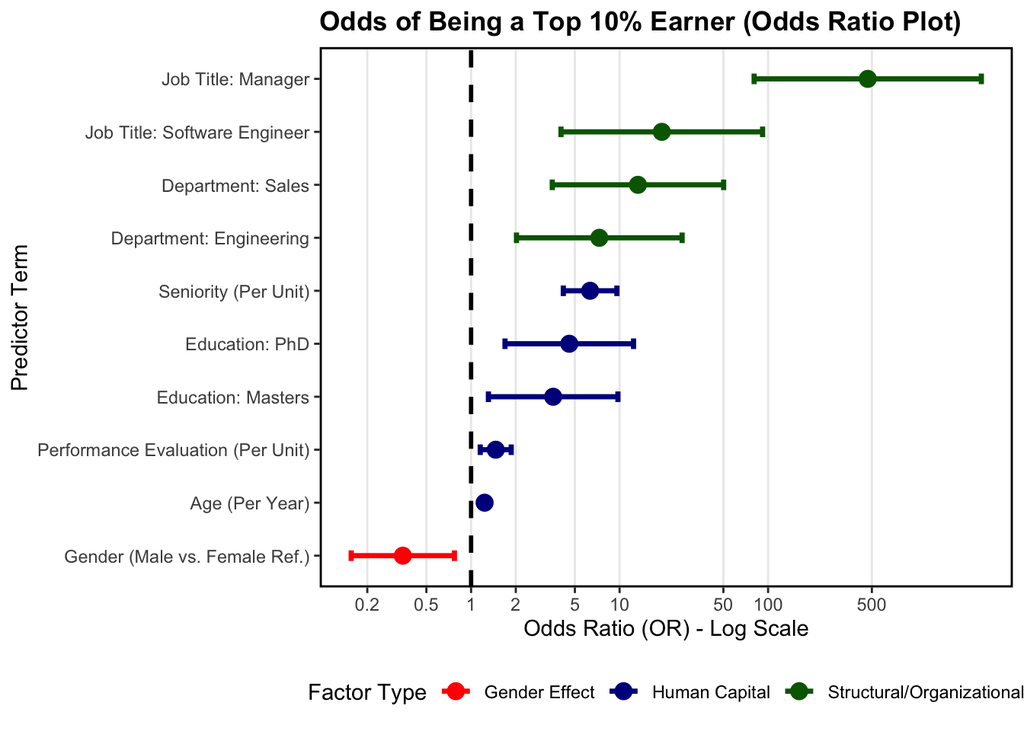

```r
# 1. Install and load necessary packages
# install.packages(c("ggplot2", "dplyr"))
library(stringr) # Used for cleaning labels

# 2. Manually input the significant data from your RQ4 model (p < 0.05)
# Includes Estimate, Std. Error for CI calculation, and Term for labeling.
df_data <- data.frame(
  Term = c("JobTitleManager", "JobTitleSoftware Engineer", "DeptSales", "Seniority",
           "EducationPhD", "EducationMasters", "DeptEngineering", "PerfEval",
           "Age", "GenderMale"),
  Estimate = c(6.15045, 2.95718, 2.58741, 1.84565, 1.52265, 1.27290, 1.98807, 0.38201,
               0.20982, -1.05857),
  Std_Error = c(0.89877, 0.79740, 0.67777, 0.21204, 0.50842, 0.51223, 0.65513, 0.12250,
                0.02427, 0.40827)
)

# 3. Calculate OR and 95% Confidence Intervals (CI)
df_plot <- df_data %>%
  mutate(
    OR = exp(Estimate),
    Lower_CI = exp(Estimate - 1.96 * Std_Error), # 1.96 for 95% CI
    Upper_CI = exp(Estimate + 1.96 * Std_Error)
  )

# 4. Prepare Labels and Color Groups
df_plot <- df_plot %>%
  # Create clean labels for the y-axis
  mutate(
    Term_Label = case_when(
      Term == "GenderMale" ~ "Gender (Male vs. Female Ref.)",
      Term == "Seniority" ~ "Seniority (Per Unit)",
      Term == "PerfEval" ~ "Performance Evaluation (Per Unit)",
      Term == "Age" ~ "Age (Per Year)",
      TRUE ~ str_replace_all(Term, c("JobTitle" = "Job Title: ", "Dept" = "Department: ", "Education" = "Education: "))
    ),
    # Define colors
    Group = case_when(
      Term == "GenderMale" ~ "Gender Effect",
      str_detect(Term, "JobTitle|Dept") ~ "Structural/Organizational",
      TRUE ~ "Human Capital"
    )
  ) %>%
  # Sort the plot by OR magnitude (ascending for plot order)
  arrange(desc(OR))

# Convert Term_Label to a factor with the correct order
df_plot$Term_Label <- factor(df_plot$Term_Label, levels = rev(df_plot$Term_Label))


# 5. Generate the Plot using ggplot2
ggplot(df_plot, aes(x = OR, y = Term_Label, color = Group)) +

  # Plot the confidence intervals (the sharp lines)
  geom_errorbarh(aes(xmin = Lower_CI, xmax = Upper_CI), height = 0.2, size = 1.2) +

  # Plot the point estimate (the sharp dot)
  geom_point(size = 3.5) +

  # Add the vertical line at OR = 1 (no effect)
  geom_vline(xintercept = 1, linetype = "dashed", color = "black", linewidth = 1) +

  # Use log scale for the X-axis and define ticks for readability
  scale_x_log10(
    breaks = c(0.2, 0.5, 1, 2, 5, 10, 50, 100, 500),
    labels = c("0.2", "0.5", "1", "2", "5", "10", "50", "100", "500")
  ) +

  # Define custom colors
  scale_color_manual(values = c("Gender Effect" = "red",
                                "Structural/Organizational" = "darkgreen",
                                "Human Capital" = "darkblue")) +

  # Labels and Title
  labs(
    title = "Odds of Being a Top 10% Earner (Odds Ratio Plot)",
    x = "Odds Ratio (OR) - Log Scale",
    y = "Predictor Term",
    color = "Factor Type"
  ) +

  # Use a theme for sharp edges (theme_bw is a good choice)
  theme_bw() +
  theme(
    panel.grid.minor.x = element_blank(), # Remove minor grid lines
    panel.grid.major.y = element_blank(), # Remove horizontal grid lines
    panel.border = element_rect(color = "black", linewidth = 1), # Sharp border
    legend.position = "bottom",
    plot.title = element_text(face = "bold")
  )
```